# Notebook Imports

```python
import numpy as np
import pandas as pd
import matplotlib.pyplot as plt
import seaborn as sns
import math

from sklearn.model_selection import train_test_split
from sklearn.metrics import mean_squared_error, mean_absolute_error, r2_score
from xgboost import XGBRegressor


import matplotlib.style
import matplotlib as mpl
mpl.style.use('ggplot')
import scipy.stats as ss
```

# Gathering Data

The dataset was found on kaggle, and it comes from the [Ames Housing dataset](http://www.amstat.org/publications/jse/v19n3/decock.pdf).  
The Ames Housing dataset was compiled by Dean De Cock for use in data science education. It's an incredible alternative for data scientists looking for a modernized and expanded version of the often cited Boston Housing dataset.

```python
data = pd.read_csv('/kaggle/input/house-prices-advanced-regression-techniques/train.csv')
testdata = pd.read_csv('/kaggle/input/house-prices-advanced-regression-techniques/test.csv')
```

# Data exploration

```python
data.head()
```

|  | Id | MSSubClass | MSZoning | LotFrontage | LotArea | Street | Alley | LotShape | LandContour | Utilities | ... | PoolArea | PoolQC | Fence | MiscFeature | MiscVal | MoSold | YrSold | SaleType | SaleCondition | SalePrice |
| --- | --- | --- | --- | --- | --- | --- | --- | --- | --- | --- | --- | --- | --- | --- | --- | --- | --- | --- | --- | --- | --- |
| 0 | 1 | 60 | RL | 65.0 | 8450 | Pave | NaN | Reg | Lvl | AllPub | ... | 0 | NaN | NaN | NaN | 0 | 2 | 2008 | WD | Normal | 208500 |
| 1 | 2 | 20 | RL | 80.0 | 9600 | Pave | NaN | Reg | Lvl | AllPub | ... | 0 | NaN | NaN | NaN | 0 | 5 | 2007 | WD | Normal | 181500 |
| 2 | 3 | 60 | RL | 68.0 | 11250 | Pave | NaN | IR1 | Lvl | AllPub | ... | 0 | NaN | NaN | NaN | 0 | 9 | 2008 | WD | Normal | 223500 |
| 3 | 4 | 70 | RL | 60.0 | 9550 | Pave | NaN | IR1 | Lvl | AllPub | ... | 0 | NaN | NaN | NaN | 0 | 2 | 2006 | WD | Abnorml | 140000 |
| 4 | 5 | 60 | RL | 84.0 | 14260 | Pave | NaN | IR1 | Lvl | AllPub | ... | 0 | NaN | NaN | NaN | 0 | 12 | 2008 | WD | Normal | 250000 |

5 rows × 81 columns

```python
quantitative = [f for f in data.columns if data.dtypes[f] != 'object']
quantitative.remove('SalePrice')
quantitative.remove('Id')
categorical = [f for f in data.columns if data.dtypes[f] == 'object']
print(f'Quantitative Features: \n{quantitative}\n\n')
print(f'Categorical Features: \n{categorical}\n\n')
print(f'{data.shape[0]} instances of data, {len(quantitative)} quantitative features, {len(categorical)} categorical features, and target SalePrice')
```

```
Quantitative Features:
['MSSubClass', 'LotFrontage', 'LotArea', 'OverallQual', 'OverallCond', 'YearBuilt', 'YearRemodAdd', 'MasVnrArea', 'BsmtFinSF1', 'BsmtFinSF2', 'BsmtUnfSF', 'TotalBsmtSF', '1stFlrSF', '2ndFlrSF', 'LowQualFinSF', 'GrLivArea', 'BsmtFullBath', 'BsmtHalfBath', 'FullBath', 'HalfBath', 'BedroomAbvGr', 'Kitc…


Categorical Features:
['MSZoning', 'Street', 'Alley', 'LotShape', 'LandContour', 'Utilities', 'LotConfig', 'LandSlope', 'Neighborhood', 'Condition1', 'Condition2', 'BldgType', 'HouseStyle', 'RoofStyle', 'RoofMatl', 'Exterior1st', 'Exterior2nd', 'MasVnrType', 'ExterQual', 'ExterCond', 'Foundation', 'BsmtQual', 'BsmtCond',…


1460 instances of data, 36 quantitative features, 43 categorical features, and target SalePrice
```

## Null Values

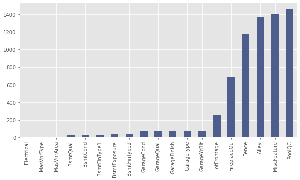

```python
nullvals = data.isnull().sum()
nullvals = nullvals[nullvals > 0]
nullvals.sort_values(inplace=True)
plt.figure(figsize=(10,5))
nullvals.plot.bar(color='#4d5d8c')
```

```python
missing_cat = [missing for missing in nullvals.index if missing in categorical]
missing_quant = [missing for missing in nullvals.index if missing in quantitative]
data[missing_quant]
```

|  | MasVnrArea | GarageYrBlt | LotFrontage |
| --- | --- | --- | --- |
| 0 | 196.0 | 2003.0 | 65.0 |
| 1 | 0.0 | 1976.0 | 80.0 |
| 2 | 162.0 | 2001.0 | 68.0 |
| 3 | 0.0 | 1998.0 | 60.0 |
| 4 | 350.0 | 2000.0 | 84.0 |
| ... | ... | ... | ... |
| 1455 | 0.0 | 1999.0 | 62.0 |
| 1456 | 119.0 | 1978.0 | 85.0 |
| 1457 | 0.0 | 1941.0 | 66.0 |
| 1458 | 0.0 | 1950.0 | 68.0 |
| 1459 | 0.0 | 1965.0 | 75.0 |

1460 rows × 3 columns

```python
data[missing_quant].describe()
```

|  | MasVnrArea | GarageYrBlt | LotFrontage |
| --- | --- | --- | --- |
| count | 1452.000000 | 1379.000000 | 1201.000000 |
| mean | 103.685262 | 1978.506164 | 70.049958 |
| std | 181.066207 | 24.689725 | 24.284752 |
| min | 0.000000 | 1900.000000 | 21.000000 |
| 25% | 0.000000 | 1961.000000 | 59.000000 |
| 50% | 0.000000 | 1980.000000 | 69.000000 |
| 75% | 166.000000 | 2002.000000 | 80.000000 |
| max | 1600.000000 | 2010.000000 | 313.000000 |

According to the data description, the null values for the categorical data correspond to not having that feature in the house, so filling that with a new categorical value, DNE, should be a good treatment.

```python
data[missing_quant] = data[missing_quant].fillna(value=0)
```

```python
data[missing_quant].isnull().any()
```

```
MasVnrArea     False
GarageYrBlt    False
LotFrontage    False
dtype: bool
```

```python
data[missing_cat] = data[missing_cat].fillna(value='DNE')
data[missing_cat].head()
```

|  | Electrical | MasVnrType | BsmtQual | BsmtCond | BsmtFinType1 | BsmtExposure | BsmtFinType2 | GarageCond | GarageQual | GarageFinish | GarageType | FireplaceQu | Fence | Alley | MiscFeature | PoolQC |
| --- | --- | --- | --- | --- | --- | --- | --- | --- | --- | --- | --- | --- | --- | --- | --- | --- |
| 0 | SBrkr | BrkFace | Gd | TA | GLQ | No | Unf | TA | TA | RFn | Attchd | DNE | DNE | DNE | DNE | DNE |
| 1 | SBrkr | None | Gd | TA | ALQ | Gd | Unf | TA | TA | RFn | Attchd | TA | DNE | DNE | DNE | DNE |
| 2 | SBrkr | BrkFace | Gd | TA | GLQ | Mn | Unf | TA | TA | RFn | Attchd | TA | DNE | DNE | DNE | DNE |
| 3 | SBrkr | None | TA | Gd | ALQ | No | Unf | TA | TA | Unf | Detchd | Gd | DNE | DNE | DNE | DNE |
| 4 | SBrkr | BrkFace | Gd | TA | GLQ | Av | Unf | TA | TA | RFn | Attchd | TA | DNE | DNE | DNE | DNE |

```python
data.isnull().any().sum()
```

```
0
```

# Visualizing Dataset

## SalePrice

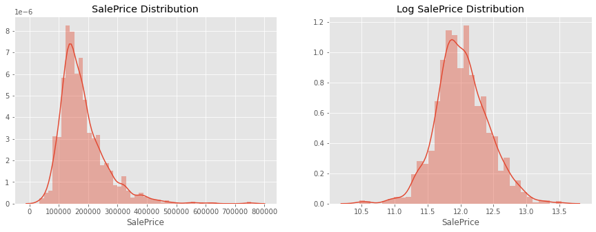

```python
plt.figure(figsize=(15,5))

plt.subplot(1, 2, 1)
y = data['SalePrice']
plt.title('SalePrice Distribution')
sns.distplot(y)

plt.subplot(1, 2, 2)
y = np.log(data['SalePrice'])
plt.title('Log SalePrice Distribution')
sns.distplot(y)
```

*SalePrice* has some outliers which could be pulled in with a log transformation.

## Quantitative Data

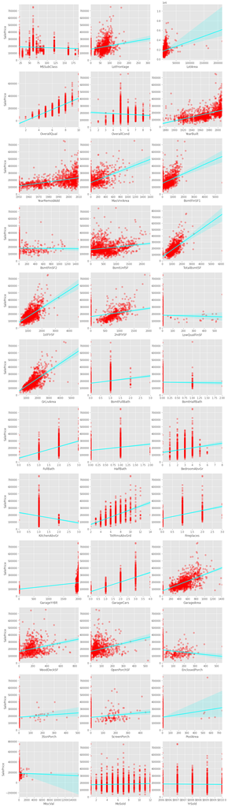

```python
rows = math.ceil(len(quantitative)/3)

plt.figure(figsize=(15, 5*rows))

for n in range(0, len(quantitative)):
    plt.subplot(rows, 3, n+1)
    sns.regplot(x=data[quantitative[n]], y=data.SalePrice, line_kws={'color':'cyan'}, scatter_kws={'color':'red', 'alpha': 0.3})
    if n%3 > 0:
        plt.ylabel('')

plt.show()
```

*MSSubClass* is the type of dwelling, and it is identified by numbers. This feature could be re ordered, but is probably best made into a categorical feature as that's what it really is.

*KitchenAbvGr* also has a strange behavior since the majority have 1, so it's highly influenced by the tail of the distribution. *OverallCond* suffers from a similar problem, and the regression line is the opposite of what we expect. These are good candidates for a transformation or removal.

*GarageYrBlt* seems to suffer from the 0s we filled in for null values. This feature is potentially be represented in *GarageCars* or *GarageArea* along with *YearBuilt*, and removed entirely or fill in the null values with something else. Two possibilities are the mean of the other values, or the *YearBuilt*. *YearBuilt* is what we will try first.

```python
for n in range(0, len(data.GarageYrBlt)):
    if data.GarageYrBlt[n] == 0:
        data.loc[n, 'GarageYrBlt'] = data.YearBuilt[n]
```

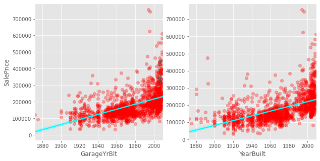

```python
plt.figure(figsize=(10,5))

plt.subplot(1, 2, 1)
sns.regplot(x=data.GarageYrBlt, y=data.SalePrice, line_kws={'color':'cyan'}, scatter_kws={'color':'red', 'alpha': 0.3})

plt.subplot(1, 2, 2)
sns.regplot(x=data.YearBuilt, y=data.SalePrice, line_kws={'color':'cyan'}, scatter_kws={'color':'red', 'alpha': 0.3})
plt.show()
```

After setting the zero values in *GarageYrBlt* to the values of *YearBuilt*, the graph for *GarageYrBlt* appears to be a more well behaved feature. It is very similar to **YearBuilt** and may or may not improve the model by dropping *GarageYrBlt*.

```python
for n in range(0, len(data.MSSubClass)):
    data.loc[n, 'MSSubClass'] = str(data.MSSubClass[n])
categorical.append('MSSubClass')
quantitative.remove('MSSubClass')
```

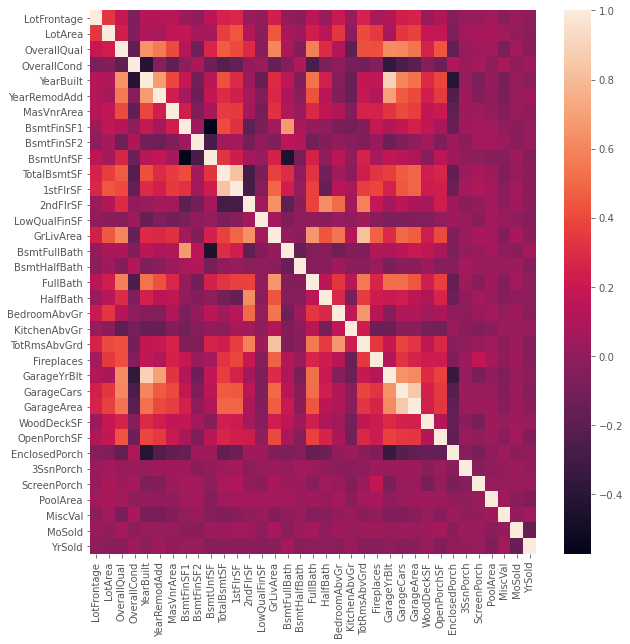

```python
plt.figure(figsize=(10,10))
corr = data[quantitative].corr('spearman')
sns.heatmap(corr)
```

```python
corr['YearBuilt']['GarageYrBlt']
```

```
0.8952246204868528
```

*YearBuilt* and *GarageYrBlt* have a high correlation, further evidence the model may benefit from removing *GarageYrBlt*

# Categorical Data

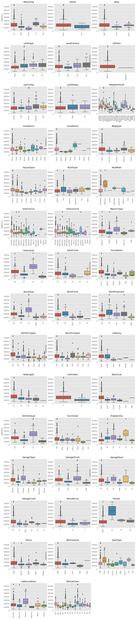

```python
rows = math.ceil(len(categorical)/3)
plt.figure(figsize=(15,5*rows))

for n in range(0, len(categorical)):

    plt.subplot(rows, 3, n+1)
    sns.boxplot(x=data[categorical[n]], y=data.SalePrice)
    x=plt.xticks(rotation=90)
    plt.xlabel('')
    plt.title(f'{categorical[n]}')
    if n%5 > 0:
        plt.ylabel('')
        plt.yticks(ticks=None, labels=None)


plt.subplots_adjust(hspace=0.5)
plt.show()
```

We will be using OneHotEncoding for the categorical data which is going to create a massive amount of new variables, and may overtrain out model. Another potential approach is encoding the categories in each feature as their mean with respect to the *SalePrice*.

```python
one_hot = pd.get_dummies(data[categorical], drop_first=True)
one_hot
```

|  | MSZoning_FV | MSZoning_RH | MSZoning_RL | MSZoning_RM | Street_Pave | Alley_Grvl | Alley_Pave | LotShape_IR2 | LotShape_IR3 | LotShape_Reg | ... | MSSubClass_30 | MSSubClass_40 | MSSubClass_45 | MSSubClass_50 | MSSubClass_60 | MSSubClass_70 | MSSubClass_75 | MSSubClass_80 | MSSubClass_85 | MSSubClass_90 |
| --- | --- | --- | --- | --- | --- | --- | --- | --- | --- | --- | --- | --- | --- | --- | --- | --- | --- | --- | --- | --- | --- |
| 0 | 0 | 0 | 1 | 0 | 1 | 0 | 0 | 0 | 0 | 1 | ... | 0 | 0 | 0 | 0 | 1 | 0 | 0 | 0 | 0 | 0 |
| 1 | 0 | 0 | 1 | 0 | 1 | 0 | 0 | 0 | 0 | 1 | ... | 0 | 0 | 0 | 0 | 0 | 0 | 0 | 0 | 0 | 0 |
| 2 | 0 | 0 | 1 | 0 | 1 | 0 | 0 | 0 | 0 | 0 | ... | 0 | 0 | 0 | 0 | 1 | 0 | 0 | 0 | 0 | 0 |
| 3 | 0 | 0 | 1 | 0 | 1 | 0 | 0 | 0 | 0 | 0 | ... | 0 | 0 | 0 | 0 | 0 | 1 | 0 | 0 | 0 | 0 |
| 4 | 0 | 0 | 1 | 0 | 1 | 0 | 0 | 0 | 0 | 0 | ... | 0 | 0 | 0 | 0 | 1 | 0 | 0 | 0 | 0 | 0 |
| ... | ... | ... | ... | ... | ... | ... | ... | ... | ... | ... | ... | ... | ... | ... | ... | ... | ... | ... | ... | ... | ... |
| 1455 | 0 | 0 | 1 | 0 | 1 | 0 | 0 | 0 | 0 | 1 | ... | 0 | 0 | 0 | 0 | 1 | 0 | 0 | 0 | 0 | 0 |
| 1456 | 0 | 0 | 1 | 0 | 1 | 0 | 0 | 0 | 0 | 1 | ... | 0 | 0 | 0 | 0 | 0 | 0 | 0 | 0 | 0 | 0 |
| 1457 | 0 | 0 | 1 | 0 | 1 | 0 | 0 | 0 | 0 | 1 | ... | 0 | 0 | 0 | 0 | 0 | 1 | 0 | 0 | 0 | 0 |
| 1458 | 0 | 0 | 1 | 0 | 1 | 0 | 0 | 0 | 0 | 1 | ... | 0 | 0 | 0 | 0 | 0 | 0 | 0 | 0 | 0 | 0 |
| 1459 | 0 | 0 | 1 | 0 | 1 | 0 | 0 | 0 | 0 | 1 | ... | 0 | 0 | 0 | 0 | 0 | 0 | 0 | 0 | 0 | 0 |

1460 rows × 239 columns

```python
one_hot_encoded = pd.concat([data[quantitative], one_hot], axis=1)
one_hot_encoded
```

|  | LotFrontage | LotArea | OverallQual | OverallCond | YearBuilt | YearRemodAdd | MasVnrArea | BsmtFinSF1 | BsmtFinSF2 | BsmtUnfSF | ... | MSSubClass_30 | MSSubClass_40 | MSSubClass_45 | MSSubClass_50 | MSSubClass_60 | MSSubClass_70 | MSSubClass_75 | MSSubClass_80 | MSSubClass_85 | MSSubClass_90 |
| --- | --- | --- | --- | --- | --- | --- | --- | --- | --- | --- | --- | --- | --- | --- | --- | --- | --- | --- | --- | --- | --- |
| 0 | 65.0 | 8450 | 7 | 5 | 2003 | 2003 | 196.0 | 706 | 0 | 150 | ... | 0 | 0 | 0 | 0 | 1 | 0 | 0 | 0 | 0 | 0 |
| 1 | 80.0 | 9600 | 6 | 8 | 1976 | 1976 | 0.0 | 978 | 0 | 284 | ... | 0 | 0 | 0 | 0 | 0 | 0 | 0 | 0 | 0 | 0 |
| 2 | 68.0 | 11250 | 7 | 5 | 2001 | 2002 | 162.0 | 486 | 0 | 434 | ... | 0 | 0 | 0 | 0 | 1 | 0 | 0 | 0 | 0 | 0 |
| 3 | 60.0 | 9550 | 7 | 5 | 1915 | 1970 | 0.0 | 216 | 0 | 540 | ... | 0 | 0 | 0 | 0 | 0 | 1 | 0 | 0 | 0 | 0 |
| 4 | 84.0 | 14260 | 8 | 5 | 2000 | 2000 | 350.0 | 655 | 0 | 490 | ... | 0 | 0 | 0 | 0 | 1 | 0 | 0 | 0 | 0 | 0 |
| ... | ... | ... | ... | ... | ... | ... | ... | ... | ... | ... | ... | ... | ... | ... | ... | ... | ... | ... | ... | ... | ... |
| 1455 | 62.0 | 7917 | 6 | 5 | 1999 | 2000 | 0.0 | 0 | 0 | 953 | ... | 0 | 0 | 0 | 0 | 1 | 0 | 0 | 0 | 0 | 0 |
| 1456 | 85.0 | 13175 | 6 | 6 | 1978 | 1988 | 119.0 | 790 | 163 | 589 | ... | 0 | 0 | 0 | 0 | 0 | 0 | 0 | 0 | 0 | 0 |
| 1457 | 66.0 | 9042 | 7 | 9 | 1941 | 2006 | 0.0 | 275 | 0 | 877 | ... | 0 | 0 | 0 | 0 | 0 | 1 | 0 | 0 | 0 | 0 |
| 1458 | 68.0 | 9717 | 5 | 6 | 1950 | 1996 | 0.0 | 49 | 1029 | 0 | ... | 0 | 0 | 0 | 0 | 0 | 0 | 0 | 0 | 0 | 0 |
| 1459 | 75.0 | 9937 | 5 | 6 | 1965 | 1965 | 0.0 | 830 | 290 | 136 | ... | 0 | 0 | 0 | 0 | 0 | 0 | 0 | 0 | 0 | 0 |

1460 rows × 274 columns

# Training the model

### Full Log Prices

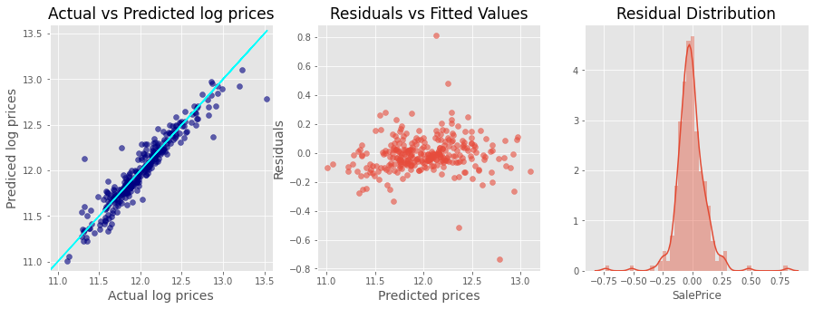

```python
# Full Model of Log Prices
X = one_hot_encoded
y = np.log(data['SalePrice'])

X_train, X_test, y_train, y_test = train_test_split(X, y, test_size=0.2, random_state=0)

my_model = XGBRegressor(n_estimators=1000, learning_rate=0.01)
my_model.fit(X_train, y_train, verbose=False)
predictions = my_model.predict(X_test)


# Graph of Actual vs Predicted Prices of Validation Set
plt.figure(figsize=(15,5))

plt.subplot(1, 3, 1)
plt.scatter(x=y_test, y=predictions, c='navy', alpha=0.6)
plt.plot(y_train, y_train, color='cyan')

plt.xlim(10.9, 13.6)
plt.ylim(10.9, 13.6)

plt.xlabel('Actual log prices', fontsize=14)
plt.ylabel('Prediced log prices', fontsize=14)
plt.title('Actual vs Predicted log prices', fontsize=17)

# Graph of Residuals of Validation Set

resid = predictions - y_test
plt.subplot(1, 3, 2)
plt.scatter(x=predictions, y=resid, c='#e74c3c', alpha=0.6)

plt.xlabel('Predicted prices', fontsize=14)
plt.ylabel('Residuals', fontsize=14)
plt.title('Residuals vs Fitted Values', fontsize=17)

# Graph of Residual Distribution of Validation Set

plt.subplot(1, 3, 3)

plt.title('Residual Distribution', fontsize=17)
sns.distplot(resid)

plt.show()
```

```python
full_log_MSE = mean_squared_error(predictions, y_test)
full_log_RMSE = np.sqrt(full_log_MSE)
full_log_r2 = r2_score(predictions, y_test)


print(f'Root Mean Squared Error: {full_log_RMSE}')
print(f'R2 Score: {full_log_r2}')
```

```
Root Mean Squared Error: 0.12528995761337852
R2 Score: 0.8915181757053858
```

# Log Prices with features removed

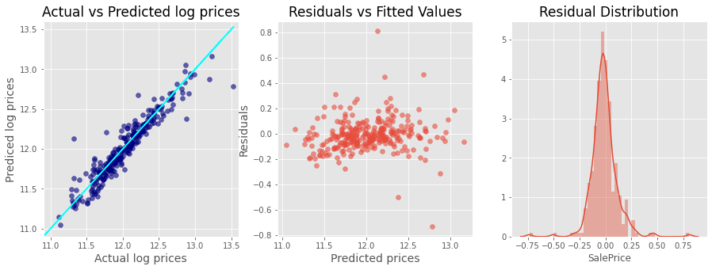

```python
# Model of Log Prices with features removed
omitted_data = one_hot_encoded.copy()
omitted_data = omitted_data.drop(['KitchenAbvGr','GarageYrBlt','OverallCond', 'LowQualFinSF', 'BsmtHalfBath', 'HalfBath', '3SsnPorch', 'MoSold', 'MiscVal', 'YrSold'], axis=1)


X = omitted_data
y = np.log(data['SalePrice'])

X_train, X_test, y_train, y_test = train_test_split(X, y, test_size=0.2, random_state=0)

my_model = XGBRegressor(n_estimators=1000, learning_rate=0.01)
my_model.fit(X_train, y_train, verbose=False)
predictions = my_model.predict(X_test)


# Graph of Actual vs Predicted Prices of Validation Set
plt.figure(figsize=(15,5))

plt.subplot(1, 3, 1)
plt.scatter(x=y_test, y=predictions, c='navy', alpha=0.6)
plt.plot(y_train, y_train, color='cyan')

plt.xlim(10.9, 13.6)
plt.ylim(10.9, 13.6)

plt.xlabel('Actual log prices', fontsize=14)
plt.ylabel('Prediced log prices', fontsize=14)
plt.title('Actual vs Predicted log prices', fontsize=17)

# Graph of Residuals of Validation Set

resid = predictions - y_test
plt.subplot(1, 3, 2)
plt.scatter(x=predictions, y=resid, c='#e74c3c', alpha=0.6)

plt.xlabel('Predicted prices', fontsize=14)
plt.ylabel('Residuals', fontsize=14)
plt.title('Residuals vs Fitted Values', fontsize=17)

# Graph of Residual Distribution of Validation Set

plt.subplot(1, 3, 3)

plt.title('Residual Distribution', fontsize=17)
sns.distplot(resid)

plt.show()
```

```python
omitted_log_MSE = mean_squared_error(predictions, y_test)
omitted_log_RMSE = np.sqrt(omitted_log_MSE)
omitted_log_r2 = r2_score(predictions, y_test)


print(f'Root Mean Squared Error: {omitted_log_RMSE}')
print(f'R2 Score: {omitted_log_r2}')
```

```
Root Mean Squared Error: 0.1276460940383743
R2 Score: 0.8889425136122967
```

# Full Model of Log Prices with transformed features

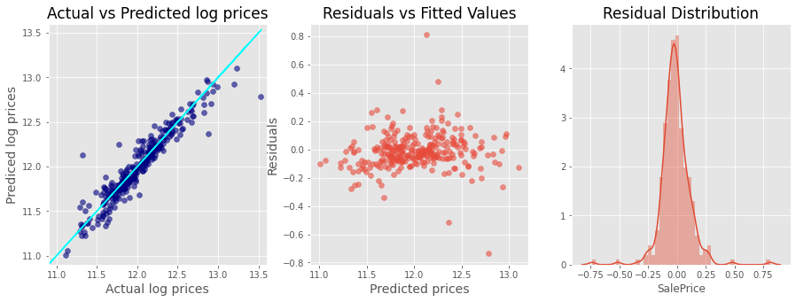

```python
# Full Model of Log Prices with transformed features

# Feature transformations
transformed_data = one_hot_encoded.copy()

def log(feature):
    transformed_data[feature] = np.log1p(transformed_data[feature].values)

def quadratic(feature):
    transformed_data[feature+'_squared'] = transformed_data[feature]**2


log('GrLivArea')
log('1stFlrSF')
log('2ndFlrSF')
log('TotalBsmtSF')
log('LotArea')
log('LotFrontage')
log('KitchenAbvGr')
log('GarageArea')

quadratic('OverallQual')
quadratic('YearBuilt')
quadratic('YearRemodAdd')
quadratic('TotalBsmtSF')
quadratic('2ndFlrSF')
quadratic('GrLivArea')

transformed_data['HasBasement'] = transformed_data['TotalBsmtSF'].apply(lambda x: 1 if x > 0 else 0)
transformed_data['HasGarage'] = transformed_data['GarageArea'].apply(lambda x: 1 if x > 0 else 0)
transformed_data['Has2ndFloor'] = transformed_data['2ndFlrSF'].apply(lambda x: 1 if x > 0 else 0)
transformed_data['HasMasVnr'] = transformed_data['MasVnrArea'].apply(lambda x: 1 if x > 0 else 0)
transformed_data['HasWoodDeck'] = transformed_data['WoodDeckSF'].apply(lambda x: 1 if x > 0 else 0)
transformed_data['HasPorch'] = transformed_data['OpenPorchSF'].apply(lambda x: 1 if x > 0 else 0)
transformed_data['HasPool'] = transformed_data['PoolArea'].apply(lambda x: 1 if x > 0 else 0)

X = transformed_data
y = np.log(data['SalePrice'])

X_train, X_test, y_train, y_test = train_test_split(X, y, test_size=0.2, random_state=0)

my_model = XGBRegressor(n_estimators=1000, learning_rate=0.01)
my_model.fit(X_train, y_train, verbose=False)
predictions = my_model.predict(X_test)


# Graph of Actual vs Predicted Prices of Validation Set
plt.figure(figsize=(15,5))

plt.subplot(1, 3, 1)
plt.scatter(x=y_test, y=predictions, c='navy', alpha=0.6)
plt.plot(y_train, y_train, color='cyan')

plt.xlim(10.9, 13.6)
plt.ylim(10.9, 13.6)

plt.xlabel('Actual log prices', fontsize=14)
plt.ylabel('Prediced log prices', fontsize=14)
plt.title('Actual vs Predicted log prices', fontsize=17)

# Graph of Residuals of Validation Set

resid = predictions - y_test
plt.subplot(1, 3, 2)
plt.scatter(x=predictions, y=resid, c='#e74c3c', alpha=0.6)

plt.xlabel('Predicted prices', fontsize=14)
plt.ylabel('Residuals', fontsize=14)
plt.title('Residuals vs Fitted Values', fontsize=17)

# Graph of Residual Distribution of Validation Set

plt.subplot(1, 3, 3)

plt.title('Residual Distribution', fontsize=17)
sns.distplot(resid)

plt.show()
```

```python
transf_log_MSE = mean_squared_error(predictions, y_test)
transf_log_RMSE = np.sqrt(transf_log_MSE)
transf_log_r2 = r2_score(predictions, y_test)


print(f'Root Mean Squared Error: {transf_log_RMSE}')
print(f'R2 Score: {transf_log_r2}')
```

```
Root Mean Squared Error: 0.12539709814406513
R2 Score: 0.8913588151603488
```

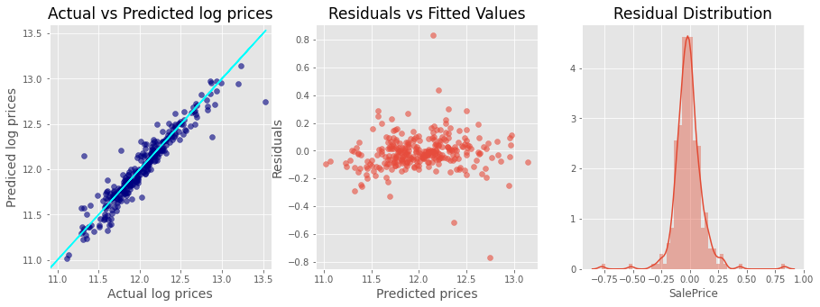

```python
# Full Model of Log Prices with transformed and omitted features

# Feature transformations
transformed_omitted_data = one_hot_encoded.copy()
transformed_omitted_data = transformed_omitted_data.drop(['KitchenAbvGr','GarageYrBlt','LowQualFinSF', 'BsmtHalfBath', 'HalfBath', '3SsnPorch', 'MoSold', 'MiscVal', 'YrSold'], axis=1)

def log(feature):
    transformed_omitted_data[feature] = np.log1p(transformed_omitted_data[feature].values)

def quadratic(feature):
    transformed_omitted_data[feature+'_squared'] = transformed_omitted_data[feature]**2


log('GrLivArea')
log('1stFlrSF')
log('2ndFlrSF')
log('TotalBsmtSF')
log('LotArea')
log('LotFrontage')
log('GarageArea')
log('OverallCond')

quadratic('OverallQual')
quadratic('YearBuilt')
quadratic('YearRemodAdd')
quadratic('TotalBsmtSF')
quadratic('2ndFlrSF')
quadratic('GrLivArea')

transformed_omitted_data['HasBasement'] = transformed_omitted_data['TotalBsmtSF'].apply(lambda x: 1 if x > 0 else 0)
transformed_omitted_data['HasGarage'] = transformed_omitted_data['GarageArea'].apply(lambda x: 1 if x > 0 else 0)
transformed_omitted_data['Has2ndFloor'] = transformed_omitted_data['2ndFlrSF'].apply(lambda x: 1 if x > 0 else 0)
transformed_omitted_data['HasMasVnr'] = transformed_omitted_data['MasVnrArea'].apply(lambda x: 1 if x > 0 else 0)
transformed_omitted_data['HasWoodDeck'] = transformed_omitted_data['WoodDeckSF'].apply(lambda x: 1 if x > 0 else 0)
transformed_omitted_data['HasPorch'] = transformed_omitted_data['OpenPorchSF'].apply(lambda x: 1 if x > 0 else 0)
transformed_omitted_data['HasPool'] = transformed_omitted_data['PoolArea'].apply(lambda x: 1 if x > 0 else 0)

X = transformed_omitted_data
y = np.log(data['SalePrice'])

X_train, X_test, y_train, y_test = train_test_split(X, y, test_size=0.2, random_state=0)

my_model = XGBRegressor(n_estimators=1000, learning_rate=0.01)
my_model.fit(X_train, y_train, verbose=False)
predictions = my_model.predict(X_test)


# Graph of Actual vs Predicted Prices of Validation Set
plt.figure(figsize=(15,5))

plt.subplot(1, 3, 1)
plt.scatter(x=y_test, y=predictions, c='navy', alpha=0.6)
plt.plot(y_train, y_train, color='cyan')

plt.xlim(10.9, 13.6)
plt.ylim(10.9, 13.6)

plt.xlabel('Actual log prices', fontsize=14)
plt.ylabel('Prediced log prices', fontsize=14)
plt.title('Actual vs Predicted log prices', fontsize=17)

# Graph of Residuals of Validation Set

resid = predictions - y_test
plt.subplot(1, 3, 2)
plt.scatter(x=predictions, y=resid, c='#e74c3c', alpha=0.6)

plt.xlabel('Predicted prices', fontsize=14)
plt.ylabel('Residuals', fontsize=14)
plt.title('Residuals vs Fitted Values', fontsize=17)

# Graph of Residual Distribution of Validation Set

plt.subplot(1, 3, 3)

plt.title('Residual Distribution', fontsize=17)
sns.distplot(resid)

plt.show()
```

```python
transf_omitted_log_MSE = mean_squared_error(predictions, y_test)
transf_omitted_log_RMSE = np.sqrt(transf_omitted_log_MSE)
transf_omitted_log_r2 = r2_score(predictions, y_test)


print(f'Root Mean Squared Error: {transf_omitted_log_RMSE}')
print(f'R2 Score: {transf_omitted_log_r2}')
```

```
Root Mean Squared Error: 0.12420613253373215
R2 Score: 0.8946081937732961
```

```python
pd.DataFrame({'R-Squared': [full_log_r2, omitted_log_r2, transf_log_r2, transf_omitted_log_r2],
             'MSE': [full_log_MSE, omitted_log_MSE, transf_log_MSE, transf_omitted_log_MSE],
             'RMSE': [full_log_RMSE, omitted_log_RMSE, transf_log_RMSE, transf_omitted_log_RMSE]},
            index=['Full Log Model', 'Omitted Var Log Model', 'Transformed Var Log Model', 'Transformed and Omitted Var Log Model'])
```

|  | R-Squared | MSE | RMSE |
| --- | --- | --- | --- |
| Full Log Model | 0.891518 | 0.015698 | 0.125290 |
| Omitted Var Log Model | 0.888943 | 0.016294 | 0.127646 |
| Transformed Var Log Model | 0.891359 | 0.015724 | 0.125397 |
| Transformed and Omitted Var Log Model | 0.894608 | 0.015427 | 0.124206 |

## Confidence interval for a house predicted to have a 300,000 dollar sale price

```python
upper_bound = np.log(300000) + 2*(transf_omitted_log_RMSE)
print('The upper bound in log prices for a 95% prediction interval is ', upper_bound)
print(f'The upper bound in normal prices is $ {np.e**upper_bound:0.2f}' )

lower_bound = np.log(300000) - 2*(transf_omitted_log_RMSE)
print('The lower bound in log prices for a 95% prediction interval is ', lower_bound)
print(f'The lower bound in normal prices is $ {np.e**lower_bound:0.2f}' )
```

```
The upper bound in log prices for a 95% prediction interval is  12.859950018705803
The upper bound in normal prices is $ 384596.50
The lower bound in log prices for a 95% prediction interval is  12.363125488570873
The lower bound in normal prices is $ 234011.49
```

# Conclusion

While the model has a fairly high R Squared value, the confidence interval is not great. The residuals have a near normal distribution if you disreguard the outliers. The models with omitted and transformed variables performed slightly worse than the full model. Combining some transformation and omissions did result in slightly better metrics, but at the cost of making the model even more complicated. The model might benefit from different omissions, transformations, or a different modeling technique entirely such as regression.